# Defaul Credit Card of Taiwan Clients in 2005

## Default of Credit Card Clients Dataset

### Overview

**Dataset Information**

This dataset contains information on default payments, demographic factors, credit data, history of payment, and bill statements of credit card clients in Taiwan from April 2005 to September 2005.

I have put the column names to lower cases. Let’s quickly look at the dataset.

- There’re quite lots of features in dataset (25 columns)
- **id** column is the client identifier, this is not important and will be removed.
- There’re few variables which I will convert to factor (such as sex, education, marriage). pay_0 and other pay_x features can considered to be factor variable, but let’s keep them as numeric for now.

```r
dim(raw.credit)
```

```
## [1] 30000    25
```

```r
summary(raw.credit)
```

```
##        id          limit_bal            sex          education
##  Min.   :    1   Min.   :  10000   Min.   :1.000   Min.   :0.000
##  1st Qu.: 7501   1st Qu.:  50000   1st Qu.:1.000   1st Qu.:1.000
##  Median :15000   Median : 140000   Median :2.000   Median :2.000
##  Mean   :15000   Mean   : 167484   Mean   :1.604   Mean   :1.853
##  3rd Qu.:22500   3rd Qu.: 240000   3rd Qu.:2.000   3rd Qu.:2.000
##  Max.   :30000   Max.   :1000000   Max.   :2.000   Max.   :6.000
##     marriage          age            pay_0             pay_2
##  Min.   :0.000   Min.   :21.00   Min.   :-2.0000   Min.   :-2.0000
##  1st Qu.:1.000   1st Qu.:28.00   1st Qu.:-1.0000   1st Qu.:-1.0000
##  Median :2.000   Median :34.00   Median : 0.0000   Median : 0.0000
##  Mean   :1.552   Mean   :35.49   Mean   :-0.0167   Mean   :-0.1338
##  3rd Qu.:2.000   3rd Qu.:41.00   3rd Qu.: 0.0000   3rd Qu.: 0.0000
##  Max.   :3.000   Max.   :79.00   Max.   : 8.0000   Max.   : 8.0000
##      pay_3             pay_4             pay_5             pay_6
##  Min.   :-2.0000   Min.   :-2.0000   Min.   :-2.0000   Min.   :-2.0000
##  1st Qu.:-1.0000   1st Qu.:-1.0000   1st Qu.:-1.0000   1st Qu.:-1.0000
##  Median : 0.0000   Median : 0.0000   Median : 0.0000   Median : 0.0000
##  Mean   :-0.1662   Mean   :-0.2207   Mean   :-0.2662   Mean   :-0.2911
##  3rd Qu.: 0.0000   3rd Qu.: 0.0000   3rd Qu.: 0.0000   3rd Qu.: 0.0000
##  Max.   : 8.0000   Max.   : 8.0000   Max.   : 8.0000   Max.   : 8.0000
##    bill_amt1         bill_amt2        bill_amt3         bill_amt4
##  Min.   :-165580   Min.   :-69777   Min.   :-157264   Min.   :-170000
##  1st Qu.:   3559   1st Qu.:  2985   1st Qu.:   2666   1st Qu.:   2327
##  Median :  22382   Median : 21200   Median :  20089   Median :  19052
##  Mean   :  51223   Mean   : 49179   Mean   :  47013   Mean   :  43263
##  3rd Qu.:  67091   3rd Qu.: 64006   3rd Qu.:  60165   3rd Qu.:  54506
##  Max.   : 964511   Max.   :983931   Max.   :1664089   Max.   : 891586
##    bill_amt5        bill_amt6          pay_amt1         pay_amt2
##  Min.   :-81334   Min.   :-339603   Min.   :     0   Min.   :      0
##  1st Qu.:  1763   1st Qu.:   1256   1st Qu.:  1000   1st Qu.:    833
##  Median : 18105   Median :  17071   Median :  2100   Median :   2009
##  Mean   : 40311   Mean   :  38872   Mean   :  5664   Mean   :   5921
##  3rd Qu.: 50191   3rd Qu.:  49198   3rd Qu.:  5006   3rd Qu.:   5000
##  Max.   :927171   Max.   : 961664   Max.   :873552   Max.   :1684259
##     pay_amt3         pay_amt4         pay_amt5           pay_amt6
##  Min.   :     0   Min.   :     0   Min.   :     0.0   Min.   :     0.0
##  1st Qu.:   390   1st Qu.:   296   1st Qu.:   252.5   1st Qu.:   117.8
##  Median :  1800   Median :  1500   Median :  1500.0   Median :  1500.0
##  Mean   :  5226   Mean   :  4826   Mean   :  4799.4   Mean   :  5215.5
##  3rd Qu.:  4505   3rd Qu.:  4013   3rd Qu.:  4031.5   3rd Qu.:  4000.0
##  Max.   :896040   Max.   :621000   Max.   :426529.0   Max.   :528666.0
##  default.payment.next.month
##  Min.   :0.0000
##  1st Qu.:0.0000
##  Median :0.0000
##  Mean   :0.2212
##  3rd Qu.:0.0000
##  Max.   :1.0000
```

```r
head(raw.credit,1)
```

```
##   id limit_bal sex education marriage age pay_0 pay_2 pay_3 pay_4 pay_5
## 1  1     20000   2         2        1  24     2     2    -1    -1    -2
##   pay_6 bill_amt1 bill_amt2 bill_amt3 bill_amt4 bill_amt5 bill_amt6
## 1    -2      3913      3102       689         0         0         0
##   pay_amt1 pay_amt2 pay_amt3 pay_amt4 pay_amt5 pay_amt6
## 1        0      689        0        0        0        0
##   default.payment.next.month
## 1                          1
```

Is there any missing data points in the dataset?

- There are no missing data.

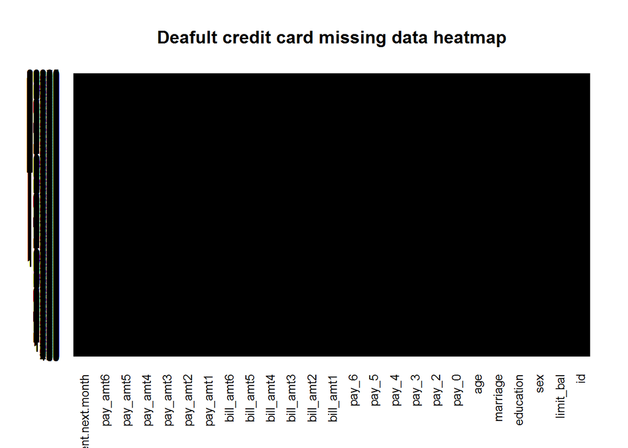

```r
missmap(raw.credit, main = "Deafult credit card missing data heatmap",
        col=c("red", "black"), legend=F)
```

```r
colSums(sapply(raw.credit, is.na))
```

```
##                         id                  limit_bal
##                          0                          0
##                        sex                  education
##                          0                          0
##                   marriage                        age
##                          0                          0
##                      pay_0                      pay_2
##                          0                          0
##                      pay_3                      pay_4
##                          0                          0
##                      pay_5                      pay_6
##                          0                          0
##                  bill_amt1                  bill_amt2
##                          0                          0
##                  bill_amt3                  bill_amt4
##                          0                          0
##                  bill_amt5                  bill_amt6
##                          0                          0
##                   pay_amt1                   pay_amt2
##                          0                          0
##                   pay_amt3                   pay_amt4
##                          0                          0
##                   pay_amt5                   pay_amt6
##                          0                          0
## default.payment.next.month
##                          0
```

Note that we have removed **id** from datasets as there’s no meaning in this context. We will proceed to next section before assigning any factor class to the variables.

### Basic Visual & Data Cleansing

This section will try to make more senses on each data point by visualization. I will also fix the data points if they are not making any senses from the given definition.

1. Look at Demographical variable data
- There are more female than male in the dataset.
- There are clients who finished university-level education.
- There are more single client than married, but the number is quite closed (53.2%:45.5%)

Recap from data definition:

- EDUCATION: (1=graduate school, 2=university, 3=high school, 4=others, 5=unknown, 6=unknown)
- MARRIAGE: Marital status (1=married, 2=single, 3=others)

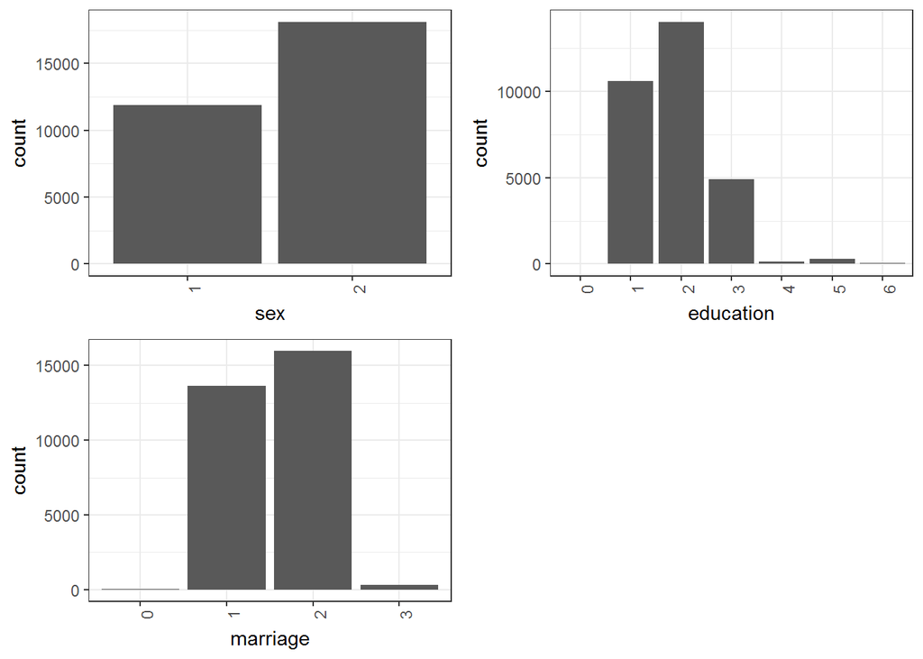

```r
# Plot Demographical data
lets.plot(raw.credit, fun=barPlot, ii=2:4, ncol=2)
```

Let’s fix the datapoint of education and marriage.

- For education, we will merge 0, 4, 5, 6 to 4 (others)
- For marriage, we will merge 0 to 3 (others)

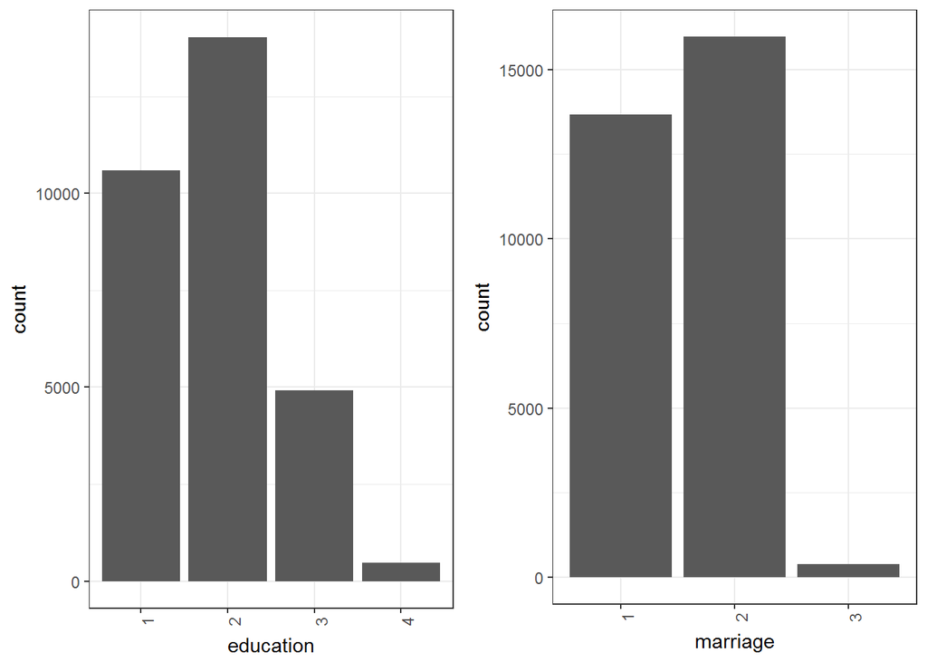

2. Age data - the data looks ok,

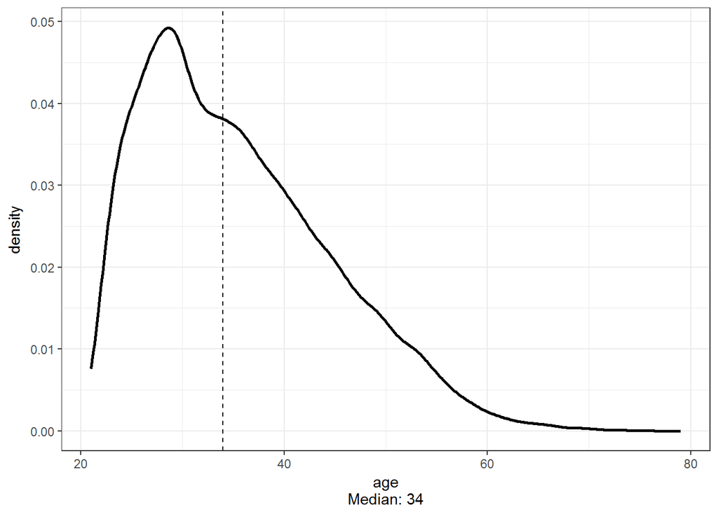

```r
lets.plot(raw.credit, fun=plotDen, ii=5, ncol=1)
```

3. Quick look on the limit balance

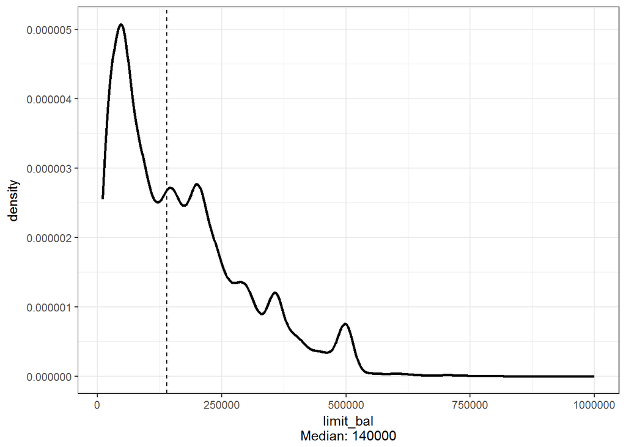

```r
lets.plot(raw.credit, fun=plotDen, ii=1, ncol=1)
```

4. What about repayment status

Based on the data definition, we have the following:

- -1 = pay duly
- 1 = payment delay for one month
- 2 = payment delay for two months

. ..

- 8 = payment delay for eight months

and so on …

However, from the plot, we can see that there are a lot of -2 and 0 data points spreading out across repayment status.

With this, I **assume** that -2, -1 and 0 have the same meaning. We will merge them to 0.

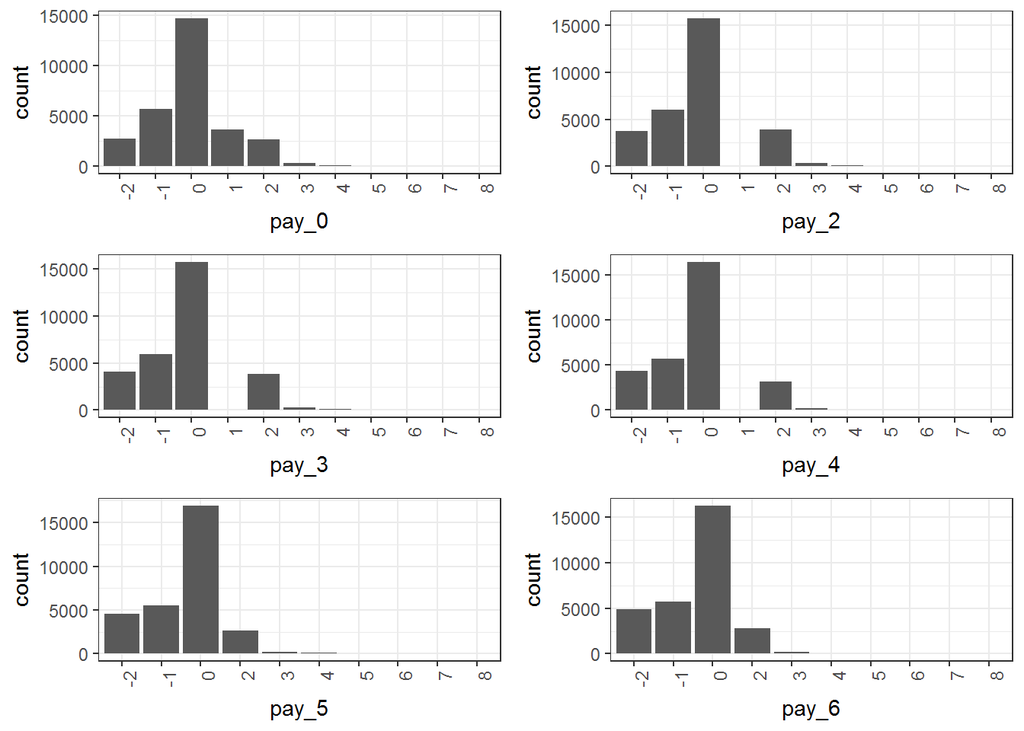

```r
lets.plot(raw.credit, fun=barPlot, ii=6:11, ncol=2)
```

```r
for (i in seq(6, 11, 1)) {
  raw.credit[which(raw.credit[[i]] %in% c(-2, -1, 0)),][[i]] <- 0
}
```

5. Let’s quickly look at the bill statement and previous payment in each month.

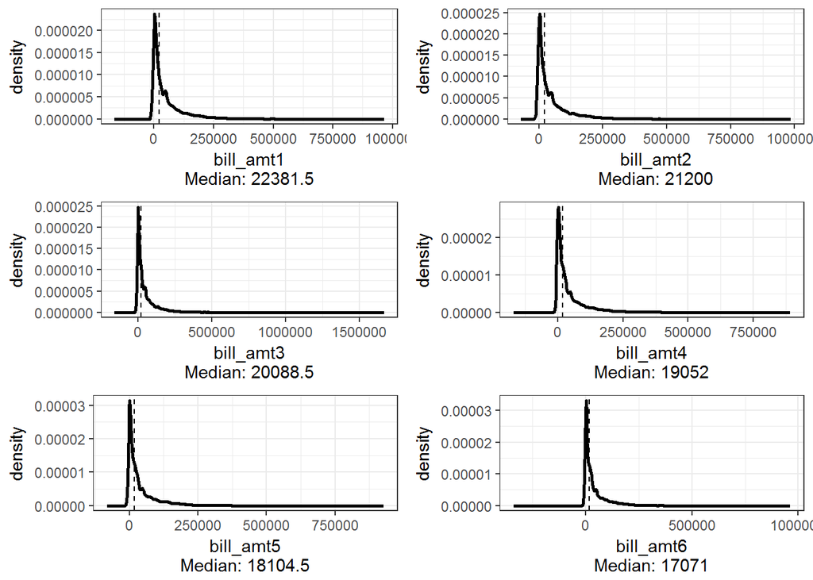

```r
lets.plot(raw.credit, fun=plotDen, ii=12:17, ncol=2)
```

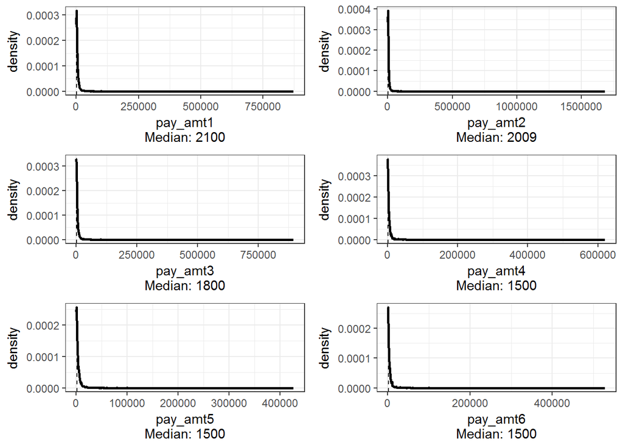

```r
lets.plot(raw.credit, fun=plotDen, ii=18:23, ncol=2)
```

6. Lastly, let’s look at the number of default payment next month.

The default payment is around 22% of the total observations in the dataset.

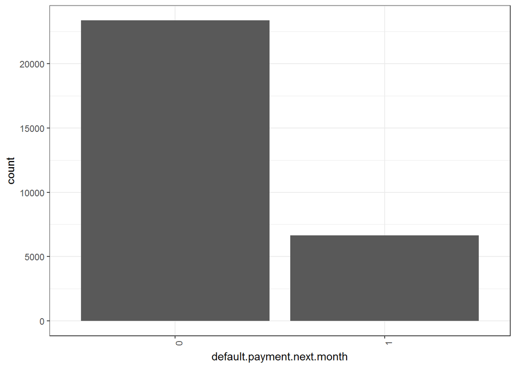

```r
lets.plot(raw.credit, fun=barPlot, ii=24, ncol=1)
```

```r
prop.table(table(raw.credit$default.payment.next.month))
```

```
##
##      0      1
## 0.7788 0.2212
```

Let’s move to the next section.

### Correlation

Let’s explore the correlation between each data points.

1. I will use the mosaicplot to visualize the demographical data against the default payment.

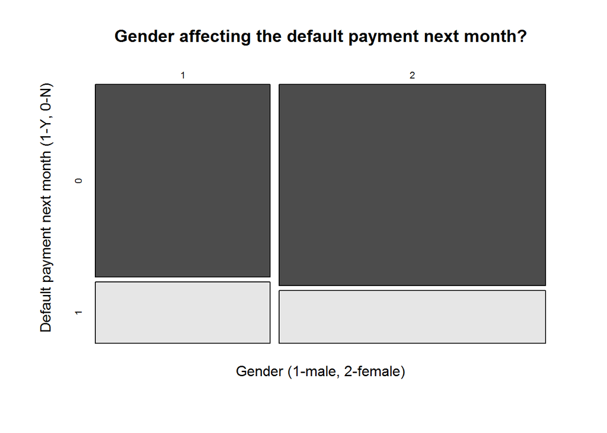

```r
mosaicplot(raw.credit$sex ~ raw.credit$default.payment.next.month, shade=F, color=T,
           main="Gender affecting the default payment next month?",
           ylab="Default payment next month (1-Y, 0-N)",
           xlab="Gender (1-male, 2-female)"
          )
```

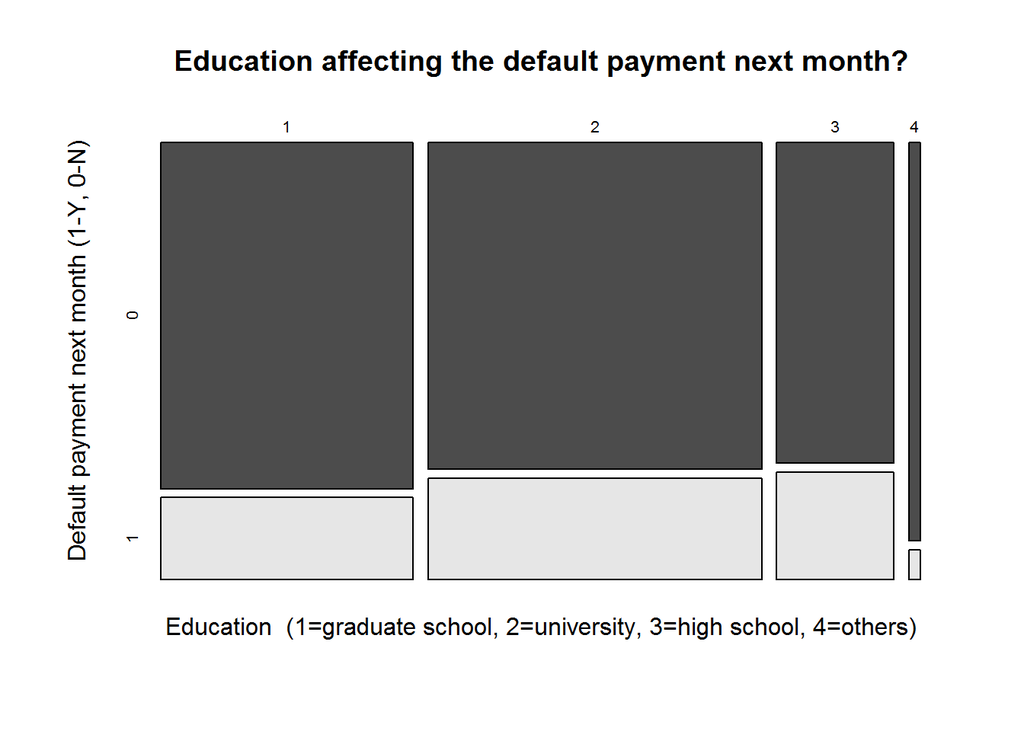

```r
mosaicplot(raw.credit$education ~ raw.credit$default.payment.next.month, shade=F, color=T,
           main="Education affecting the default payment next month?",
           ylab="Default payment next month (1-Y, 0-N)",
           xlab="Education  (1=graduate school, 2=university, 3=high school, 4=others)"
          )
```

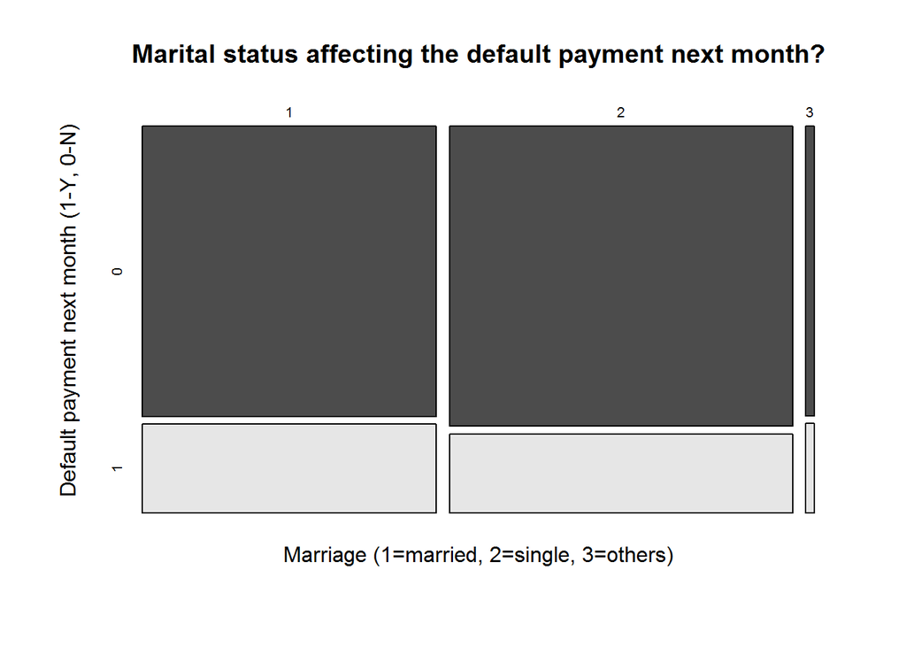

```r
mosaicplot(raw.credit$marriage ~ raw.credit$default.payment.next.month, shade=F, color=T,
           main="Marital status affecting the default payment next month?",
           ylab="Default payment next month (1-Y, 0-N)",
           xlab="Marriage (1=married, 2=single, 3=others)"
          )
```

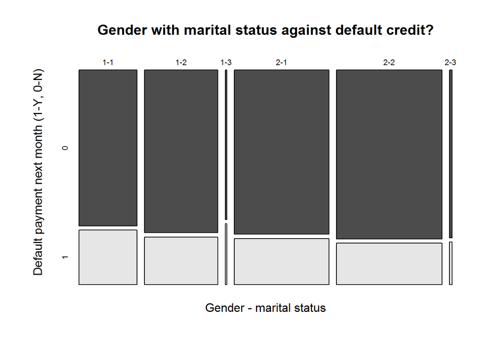

```r
mosaicplot(paste0(raw.credit$sex, '-', raw.credit$marriage) ~ raw.credit$default.payment.next.month,
           shade =F, color = T, main= "Gender with marital status against default credit?",
           xlab="Gender - marital status", ylab="Default payment next month (1-Y, 0-N)")
```

2. Let’s combine everything

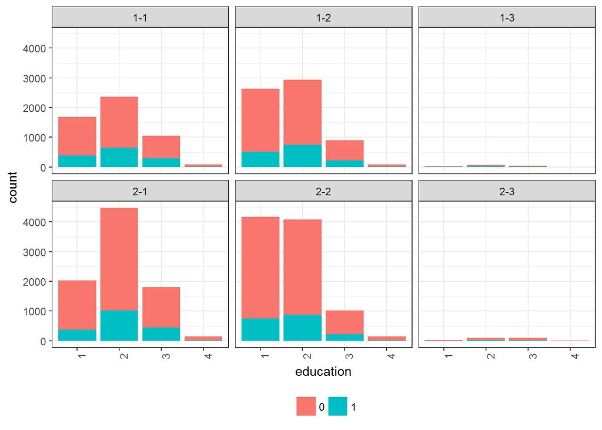

```r
ggplot(raw.credit, aes(education, fill=default.payment.next.month)) +
  stat_count() +
  facet_wrap(~paste0(raw.credit$sex, '-', raw.credit$marriage)) +
  theme_bw() +
  theme(axis.text.x = element_text(angle = 90, hjust = 1)
          , legend.position = "bottom"
          , legend.title = element_blank()
        )
```

3. Look at the repayment status of each month

From pay_0 to pay_6, the definition is the same except it is reflected the repayment status of each month (-1=pay duly, 1=payment delay for one month, 2=payment delay for two months, … 8=payment delay for eight months, 9=payment delay for nine months and above).

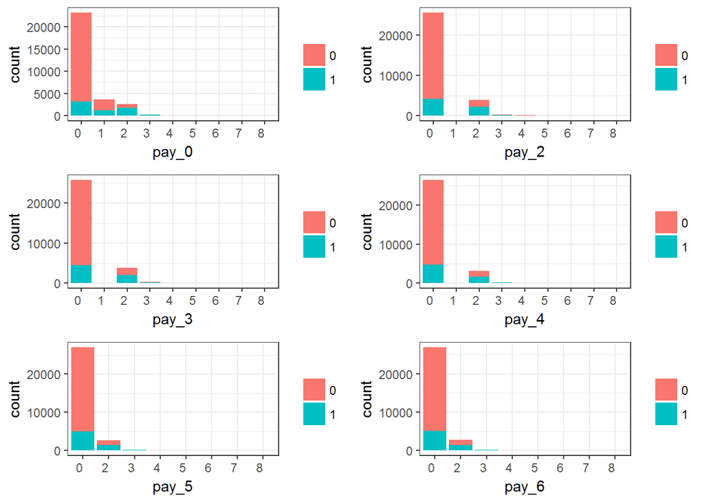

```r
repay.bar.plot <- function(df, i, target) {
  d <- data.frame(x=df[[i]])
  p <- ggplot(d, aes(factor(x), fill=df[[target]])) +
    stat_count() +
    xlab(colnames(df)[i]) +
    theme_bw() +
    theme(axis.text.x = element_text(angle = 0, hjust = 1)
          , legend.position = "right"
          , legend.title = element_blank()
    )
  return(p)
}


repayment.plot <- function(df, fun, ii, target, ncol) {
  pp <- list()
  for (i in ii) {
    p <- fun(df=df, i=i, target=target)
    pp <- c(pp, list(p))
  }
  do.call("grid.arrange", c(pp, ncol=ncol))
}

repayment.plot(raw.credit, fun=repay.bar.plot, ii=6:11, target=24, ncol=2)
```

Let’s plot some corrplot to see if the data has any correlation.

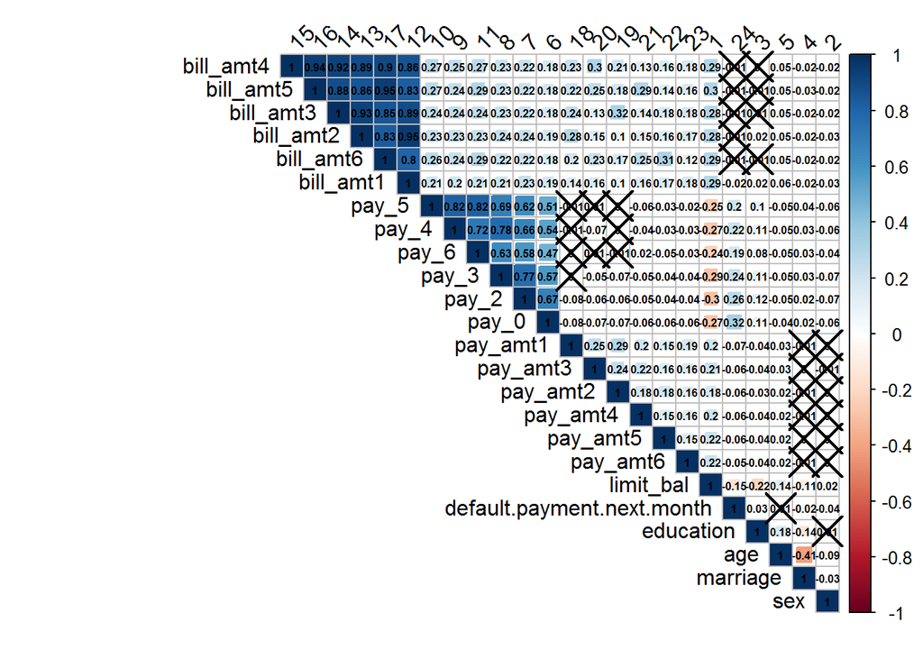

```r
credit.corr <- rcorr(as.matrix(tmp), type=c("pearson"))
colnames(credit.corr$r) <- c(1:length(colnames(credit.corr$r)))
colnames(credit.corr$P) <- c(1:length(colnames(credit.corr$P)))

corrplot(credit.corr$r, order="FPC", type="upper", method="square",
         tl.col="black", tl.srt = 45, p.mat = credit.corr$P, addCoef.col = "black",
         number.cex = 0.5, sig.level = 0.01)
```

Not much correlation to our binary **‘default.payment.next.month’** output. Let’s dive to the modeling part.

### Model Building

This section is to start building the model. Several model will be attempted to build and predict the default payment output.

Separate the dataset onto training (70%) and testing (30%).

```r
intraining <- createDataPartition(y=raw.credit$default.payment.next.month, p=0.7, list=F)
train.batch <- raw.credit[intraining,]
test.batch <- raw.credit[-intraining,]
```

```
## --- Distribution of training dataset --
```

```
##
##     0     1
## 16355  4646
```

```
##
##    0    1
## 0.78 0.22
```

```
##
## --- Distribution of training dataset --
```

```
##
##    0    1
## 7009 1990
```

```
##
##    0    1
## 0.78 0.22
```

1. Traditional Score using Logistic Regression

```r
glm.m <- glm(default.payment.next.month ~ ., data=train.batch, family=binomial)
summary(glm.m)
```

```
##
## Call:
## glm(formula = default.payment.next.month ~ ., family = binomial,
##     data = train.batch)
##
## Deviance Residuals:
##     Min       1Q   Median       3Q      Max
## -3.9556  -0.6088  -0.5292  -0.3294   3.5591
##
## Coefficients:
##                  Estimate    Std. Error z value Pr(>|z|)
## (Intercept) -1.3504568659  0.1081854533 -12.483  < 2e-16 ***
## limit_bal   -0.0000014978  0.0000001871  -8.005 1.19e-15 ***
## sex2        -0.1663682052  0.0378739559  -4.393 1.12e-05 ***
## education2  -0.0371670066  0.0435496824  -0.853  0.39342
## education3  -0.0868961122  0.0586885822  -1.481  0.13871
## education4  -1.2255061510  0.2363484631  -5.185 2.16e-07 ***
## marriage2   -0.2160475453  0.0429457452  -5.031 4.89e-07 ***
## marriage3    0.0235916669  0.1545739024   0.153  0.87869
## age          0.0028222897  0.0023154743   1.219  0.22289
## pay_0        0.8595509213  0.0299673218  28.683  < 2e-16 ***
## pay_2        0.0728778483  0.0316959208   2.299  0.02149 *
## pay_3        0.1447184961  0.0340214057   4.254 2.10e-05 ***
## pay_4        0.0187459685  0.0381015810   0.492  0.62272
## pay_5        0.1090286908  0.0407891476   2.673  0.00752 **
## pay_6        0.1475796670  0.0352592438   4.186 2.84e-05 ***
## bill_amt1   -0.0000023052  0.0000012492  -1.845  0.06497 .
## bill_amt2    0.0000016222  0.0000016789   0.966  0.33392
## bill_amt3    0.0000027890  0.0000014992   1.860  0.06283 .
## bill_amt4   -0.0000001357  0.0000014924  -0.091  0.92758
## bill_amt5   -0.0000004365  0.0000018001  -0.242  0.80843
## bill_amt6   -0.0000004912  0.0000015043  -0.326  0.74405
## pay_amt1    -0.0000118611  0.0000026623  -4.455 8.38e-06 ***
## pay_amt2    -0.0000111283  0.0000025839  -4.307 1.66e-05 ***
## pay_amt3    -0.0000006537  0.0000018498  -0.353  0.72380
## pay_amt4    -0.0000020366  0.0000020381  -0.999  0.31768
## pay_amt5    -0.0000021646  0.0000021608  -1.002  0.31647
## pay_amt6    -0.0000028094  0.0000015887  -1.768  0.07700 .
## ---
## Signif. codes:  0 '***' 0.001 '**' 0.01 '*' 0.05 '.' 0.1 ' ' 1
##
## (Dispersion parameter for binomial family taken to be 1)
##
##     Null deviance: 22196  on 21000  degrees of freedom
## Residual deviance: 18679  on 20974  degrees of freedom
## AIC: 18733
##
## Number of Fisher Scoring iterations: 6
```

```r
glm.final <- glm(default.payment.next.month ~ limit_bal+sex+education+marriage+
                   pay_0+pay_2+pay_3+pay_5+pay_6+pay_amt1+pay_amt2, data=train.batch,
                 family=binomial)
summary(glm.final)
```

```
##
## Call:
## glm(formula = default.payment.next.month ~ limit_bal + sex +
##     education + marriage + pay_0 + pay_2 + pay_3 + pay_5 + pay_6 +
##     pay_amt1 + pay_amt2, family = binomial, data = train.batch)
##
## Deviance Residuals:
##     Min       1Q   Median       3Q      Max
## -3.9593  -0.6059  -0.5281  -0.3475   3.3100
##
## Coefficients:
##                  Estimate    Std. Error z value       Pr(>|z|)
## (Intercept) -1.2464715831  0.0601064514 -20.738        < 2e-16 ***
## limit_bal   -0.0000015140  0.0000001738  -8.712        < 2e-16 ***
## sex2        -0.1739113382  0.0375086368  -4.637 0.000003542420 ***
## education2  -0.0277543002  0.0432921129  -0.641       0.521462
## education3  -0.0658065656  0.0574427500  -1.146       0.251960
## education4  -1.2000012011  0.2357514468  -5.090 0.000000357853 ***
## marriage2   -0.2404882395  0.0384488193  -6.255 0.000000000398 ***
## marriage3    0.0283120743  0.1543996255   0.183       0.854509
## pay_0        0.8688694354  0.0298363252  29.121        < 2e-16 ***
## pay_2        0.0754848440  0.0314949315   2.397       0.016542 *
## pay_3        0.1581567233  0.0303531854   5.211 0.000000188284 ***
## pay_5        0.1203090249  0.0359752028   3.344       0.000825 ***
## pay_6        0.1481768121  0.0350330573   4.230 0.000023407770 ***
## pay_amt1    -0.0000097448  0.0000023035  -4.230 0.000023324033 ***
## pay_amt2    -0.0000094181  0.0000022051  -4.271 0.000019462892 ***
## ---
## Signif. codes:  0 '***' 0.001 '**' 0.01 '*' 0.05 '.' 0.1 ' ' 1
##
## (Dispersion parameter for binomial family taken to be 1)
##
##     Null deviance: 22196  on 21000  degrees of freedom
## Residual deviance: 18708  on 20986  degrees of freedom
## AIC: 18738
##
## Number of Fisher Scoring iterations: 5
```

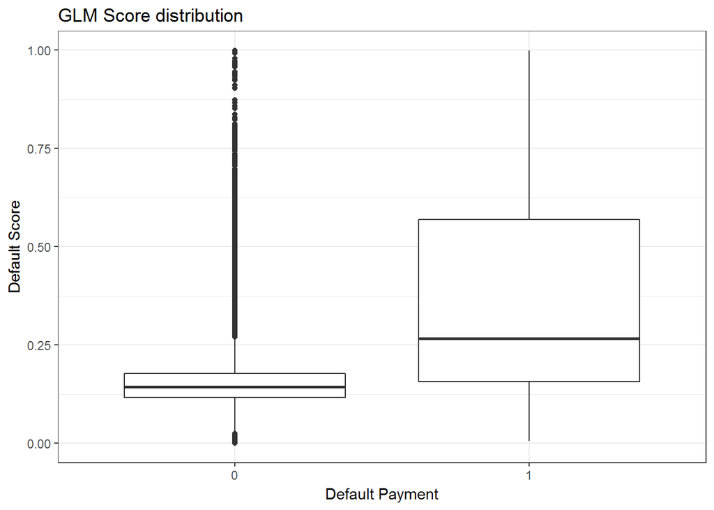

```r
test.x <- select(test.batch, - default.payment.next.month)
test.batch$glm_scor1 <- predict(glm.final, type="response", test.x)
pred <- prediction(test.batch$glm_scor1, test.batch$default.payment.next.month)
glm.perf <- performance(pred, "tpr", "fpr")

ggplot(test.batch, aes(default.payment.next.month, glm_scor1)) +
  geom_boxplot() + theme_bw() +
  ggtitle("GLM Score distribution") +
  xlab("Default Payment") +
  ylab("Default Score")
```

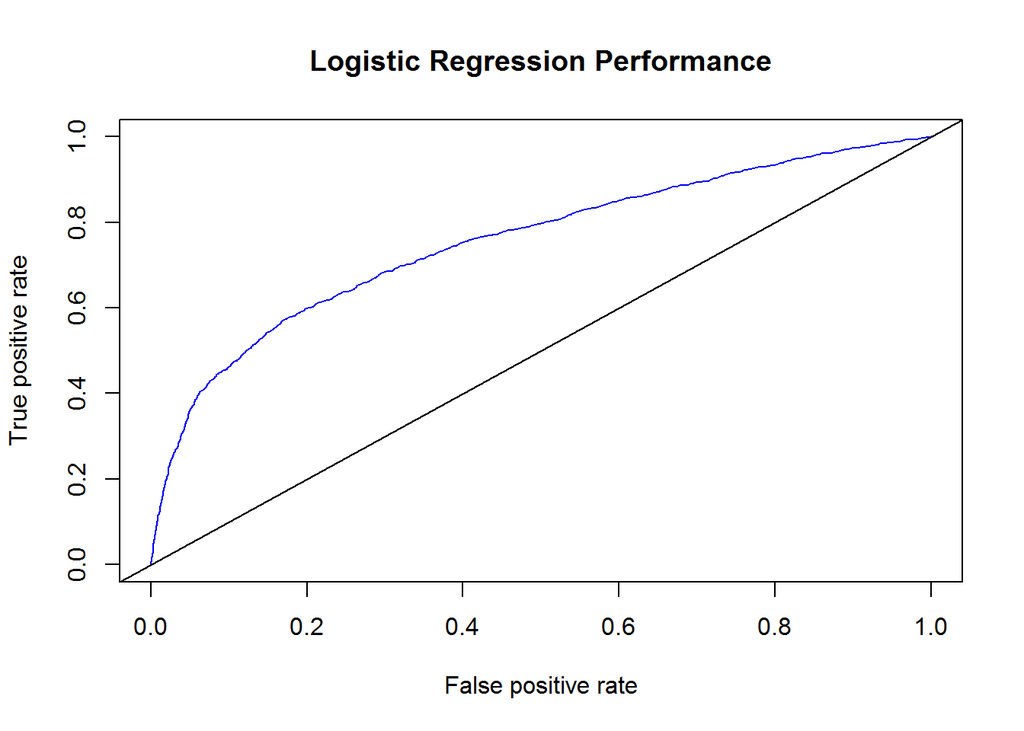

```r
# ROC
plot(glm.perf, lty=1, col="blue", main="Logistic Regression Performance")
abline(a=0, b= 1)
```

```r
auc.perf <- performance(pred, measure = "auc")
acc.perf <- performance(pred, measure = "acc")
# AUC
cat(paste0("AUC:: ", auc.perf@y.values), "\n")
```

```
## AUC:: 0.754195252191898
```

```r
# Get accuracy and cutoff
ind <- which.max( slot(acc.perf, "y.values")[[1]] )
acc <- slot(acc.perf, "y.values")[[1]][ind]
cutoff <- slot(acc.perf, "x.values")[[1]][ind]

print(c(accuracy= acc, cutoff = cutoff))
```

```
##  accuracy    cutoff
## 0.8199800 0.4538829
```

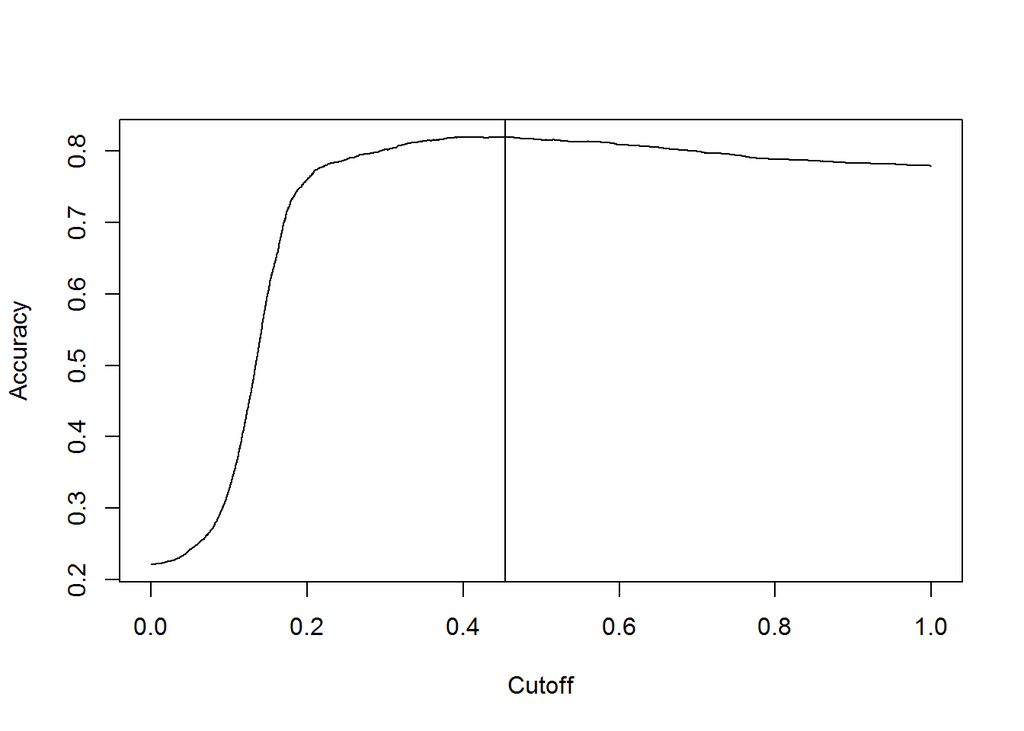

```r
# Draw Accuracy with cutoff
plot(acc.perf)
abline(v=cutoff)
```

```r
glm.scor <- select(test.batch,
                   glm_scor1,
                   default.payment.next.month)

glm.scor <- mutate(glm.scor,
                   predict_class = ifelse(glm_scor1 >= cutoff, 1, 0))

confusionMatrix(glm.scor$predict_class, glm.scor$default.payment.next.month, positive = '1')
```

```
## Confusion Matrix and Statistics
##
##           Reference
## Prediction    0    1
##          0 6659 1270
##          1  350  720
##
##                Accuracy : 0.82
##                  95% CI : (0.8119, 0.8279)
##     No Information Rate : 0.7789
##     P-Value [Acc > NIR] : < 2.2e-16
##
##                   Kappa : 0.3737
##  Mcnemar's Test P-Value : < 2.2e-16
##
##             Sensitivity : 0.36181
##             Specificity : 0.95006
##          Pos Pred Value : 0.67290
##          Neg Pred Value : 0.83983
##              Prevalence : 0.22114
##          Detection Rate : 0.08001
##    Detection Prevalence : 0.11890
##       Balanced Accuracy : 0.65594
##
##        'Positive' Class : 1
##
```

Eventually, we can see which top X variables are influenced the predicted score. In this example, I will select only top 2 variables.

```r
glm.terms <-predict(glm.final,type='terms',test.x)

get.top.var <- function(x,top=2){
  res=names(x)[order(x, decreasing = TRUE)][1:top]
  paste(res,collapse=";",sep="")
}

top.var <- apply(glm.terms, 1, get.top.var, top=2)
test.batch %>% select(default.payment.next.month, glm_scor1) %>%
  cbind(top.var) %>% head(5)
```

```
##    default.payment.next.month  glm_scor1            top.var
## 2                           1 0.19272500        pay_6;pay_2
## 5                           0 0.15253181 limit_bal;marriage
## 7                           0 0.04083023      sex;education
## 9                           0 0.19556046     pay_3;marriage
## 10                          0 0.17036448      limit_bal;sex
```

2. Decision Tree **(rpart library)**

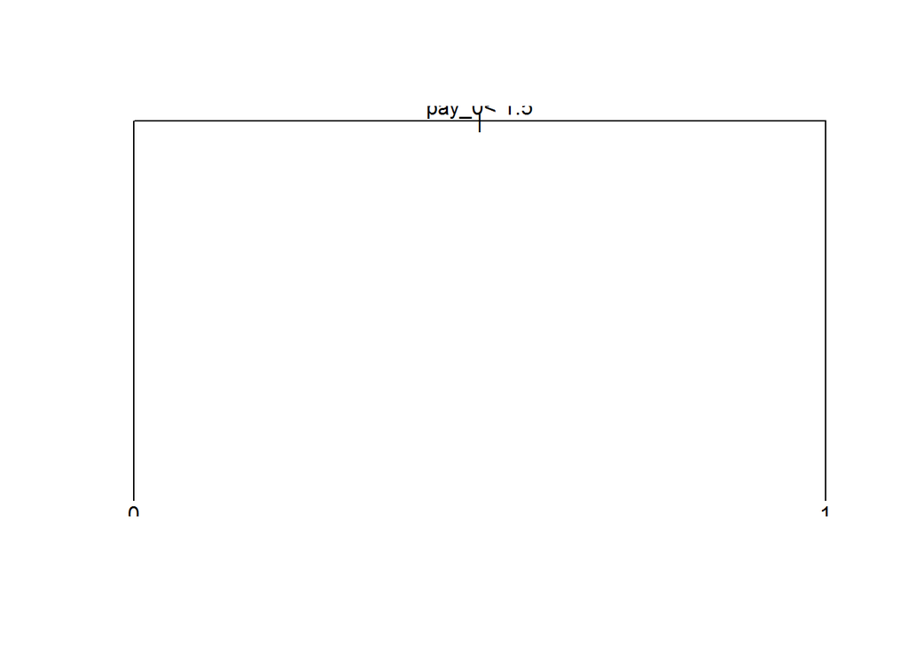

```r
library(rpart)
rpart.model <- rpart(default.payment.next.month ~.,data=train.batch)

plot(rpart.model);text(rpart.model)
```

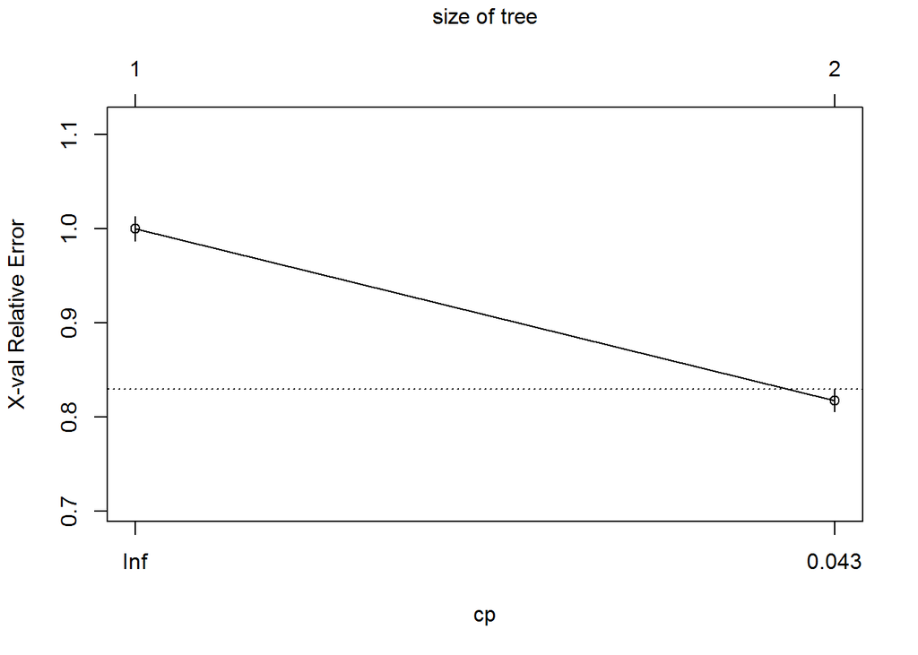

```r
plotcp(rpart.model)
```

```r
printcp(rpart.model)
```

```
##
## Classification tree:
## rpart(formula = default.payment.next.month ~ ., data = train.batch)
##
## Variables actually used in tree construction:
## [1] pay_0
##
## Root node error: 4646/21001 = 0.22123
##
## n= 21001
##
##        CP nsplit rel error  xerror     xstd
## 1 0.18252      0   1.00000 1.00000 0.012947
## 2 0.01000      1   0.81748 0.81748 0.012006
```

```r
rpart.pred <- predict(rpart.model, test.x, type="class")
confusionMatrix(rpart.pred, test.batch$default.payment.next.month, positive = '1')
```

```
## Confusion Matrix and Statistics
##
##           Reference
## Prediction    0    1
##          0 6744 1349
##          1  265  641
##
##                Accuracy : 0.8206
##                  95% CI : (0.8126, 0.8285)
##     No Information Rate : 0.7789
##     P-Value [Acc > NIR] : < 2.2e-16
##
##                   Kappa : 0.3532
##  Mcnemar's Test P-Value : < 2.2e-16
##
##             Sensitivity : 0.32211
##             Specificity : 0.96219
##          Pos Pred Value : 0.70751
##          Neg Pred Value : 0.83331
##              Prevalence : 0.22114
##          Detection Rate : 0.07123
##    Detection Prevalence : 0.10068
##       Balanced Accuracy : 0.64215
##
##        'Positive' Class : 1
##
```

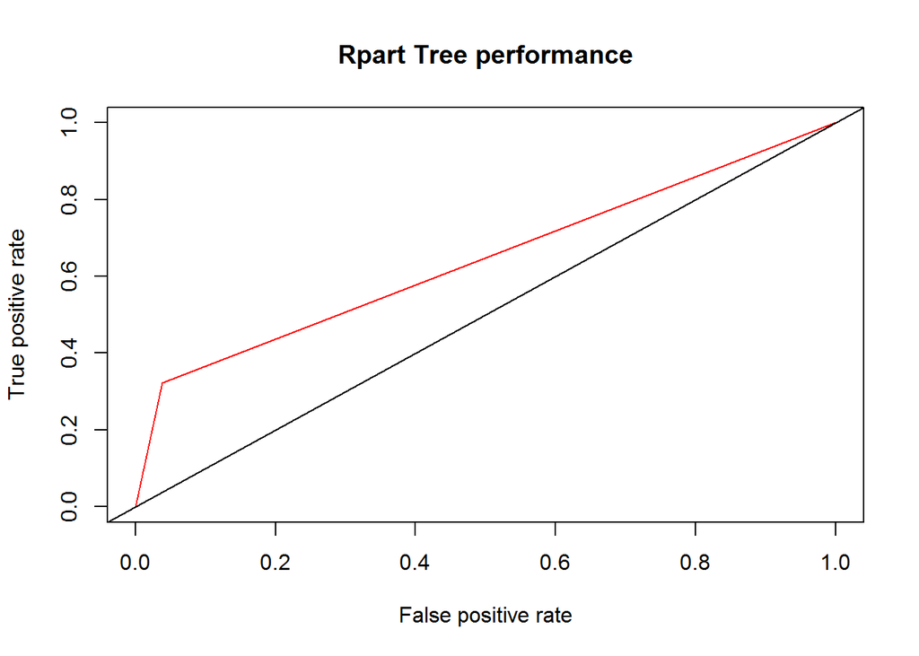

```r
test.batch$rpart_scor1 <- predict(rpart.model,type='prob',test.x)
pred2 <- prediction(test.batch$rpart_scor1[, 2], test.batch$default.payment.next.month)
rpart.perf1 <- performance(pred2,"tpr","fpr")


plot(rpart.perf1, col='red', main='Rpart Tree performance')
abline(a=0, b= 1)
```

3. Random Forest

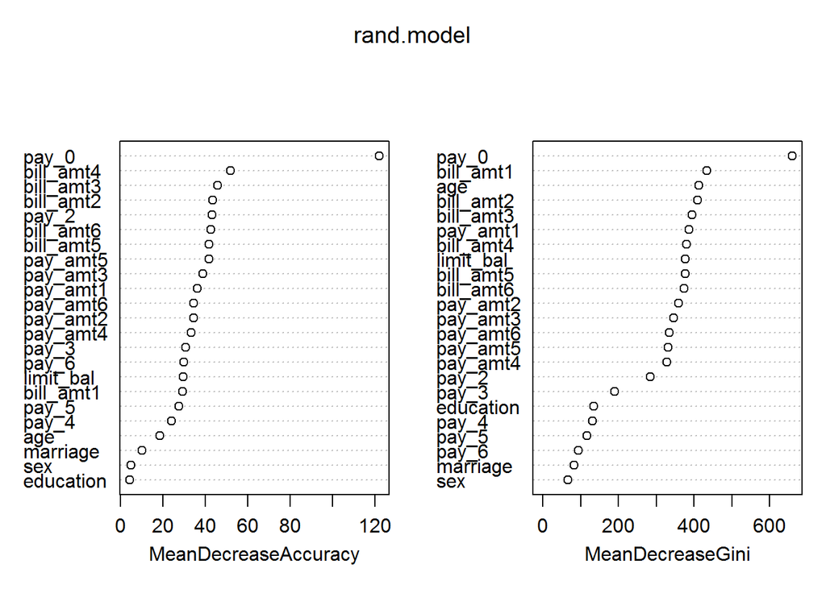

```r
library(randomForest)
rand.model <- randomForest(default.payment.next.month~.,data=train.batch, importance=T,
                            ntree=500, keep.forest=T)

varImpPlot(rand.model)
```

```r
rand.pred <- predict(rand.model, test.x, type="class")
confusionMatrix(rand.pred, test.batch$default.payment.next.month, positive='1')
```

```
## Confusion Matrix and Statistics
##
##           Reference
## Prediction    0    1
##          0 6644 1260
##          1  365  730
##
##                Accuracy : 0.8194
##                  95% CI : (0.8113, 0.8273)
##     No Information Rate : 0.7789
##     P-Value [Acc > NIR] : < 2.2e-16
##
##                   Kappa : 0.3752
##  Mcnemar's Test P-Value : < 2.2e-16
##
##             Sensitivity : 0.36683
##             Specificity : 0.94792
##          Pos Pred Value : 0.66667
##          Neg Pred Value : 0.84059
##              Prevalence : 0.22114
##          Detection Rate : 0.08112
##    Detection Prevalence : 0.12168
##       Balanced Accuracy : 0.65738
##
##        'Positive' Class : 1
##
```

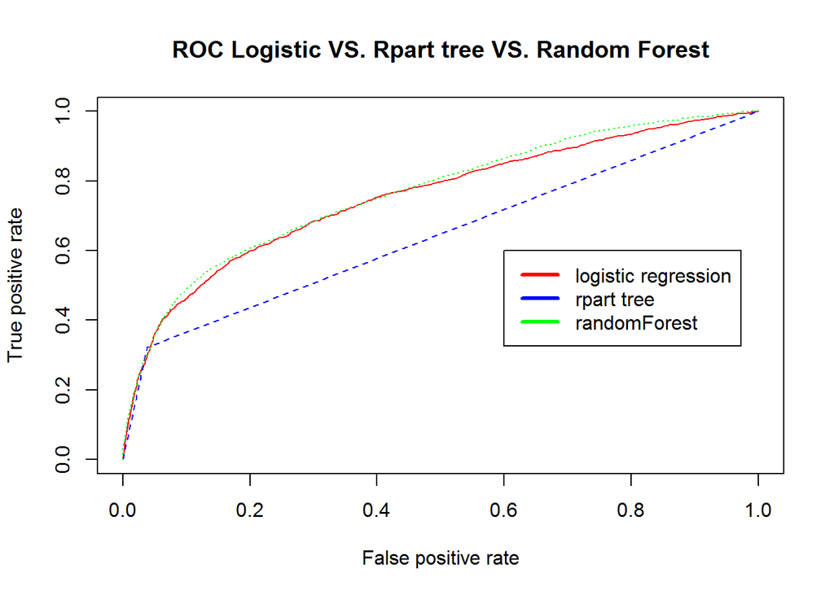

```r
rand.prob <- predict(rand.model, test.x, type='prob')[,2]
pred4 <- prediction(rand.prob,test.batch$default.payment.next.month)

rf.perf1 <- performance(pred4,"tpr","fpr")

plot(glm.perf,col='red',lty=1, main='ROC Logistic VS. Rpart tree VS. Random Forest');
plot(rpart.perf1, col='blue',lty=2,add=T);
plot(rf.perf1, col='green', lty=3, add=T);
legend(0.6,0.6,c('logistic regression','rpart tree', 'randomForest'),
       col=c('red','blue','green'),lwd=3)
```

Final print the AUC of all 3 predictions…

```r
#simple model
glm.auc <- performance(pred,"auc")
cat("\n=== Logistic Regression ===\n")
```

```
##
## === Logistic Regression ===
```

```r
cat(paste0(glm.auc@y.name,":: ", round(glm.auc@y.values[[1]], 2)))
```

```
## Area under the ROC curve:: 0.75
```

```r
cat(paste0("\nKS :: ",
           round(max(attr(glm.perf,'y.values')[[1]]-attr(glm.perf,'x.values')[[1]]),2)))
```

```
##
## KS :: 0.4
```

```r
# rpart
rpart.auc <- performance(pred2,"auc")
cat("\n\n=== Rpart tree ===\n")
```

```
##
##
## === Rpart tree ===
```

```r
cat(paste0(rpart.auc@y.name,":: ", round(rpart.auc@y.values[[1]],2)))
```

```
## Area under the ROC curve:: 0.64
```

```r
cat(paste0("\nKS :: ",
           round(max(attr(rpart.perf1,'y.values')[[1]]-attr(rpart.perf1,'x.values')[[1]]),2)))
```

```
##
## KS :: 0.28
```

```r
# RF
rf.auc <- performance(pred4,"auc")
cat("\n\n=== Random Forest ===\n")
```

```
##
##
## === Random Forest ===
```

```r
cat(paste0(rf.auc@y.name,":: ", round(rf.auc@y.values[[1]], 2)))
```

```
## Area under the ROC curve:: 0.77
```

```r
cat(paste0("\nKS :: ",
           round(max(attr(rf.perf1,'y.values')[[1]]-attr(rf.perf1,'x.values')[[1]]),2)))
```

```
##
## KS :: 0.41
```